# Final Project

## Model Diagnosis

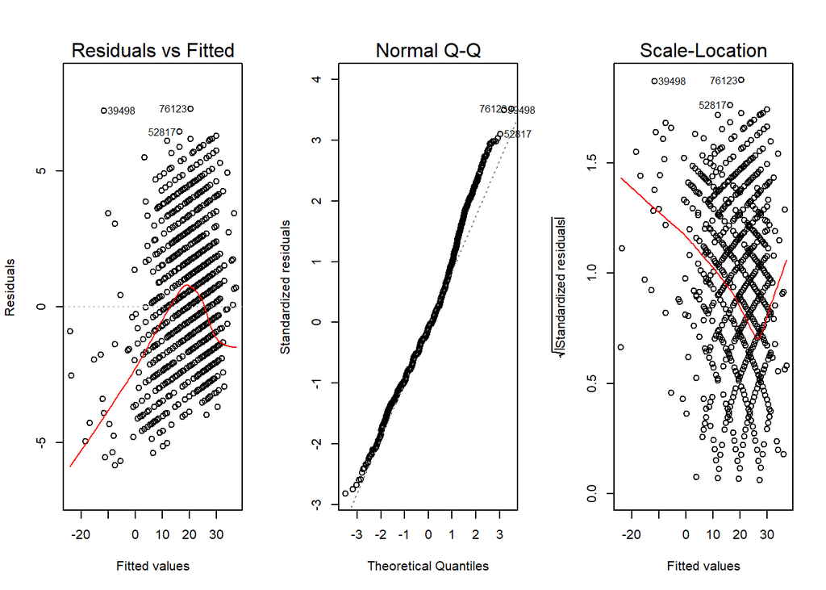

```r
par(mfrow = c(1,3))
plot(lm5, which = c(1:3,4,6))
```

```r
#Some outliers lead us to believe that there is reason to perform a robust regression
```

[figure not shown]

Cooks distance shows the negative effects of the outlines that we discussed earlier. It seems as though this data has many cases of outlines which may unfairly sway or prediction model in a way that we do not want. In fact, let us return t model selection and instead employ a robust regression to try and explain our data.

## Return to Model Selection

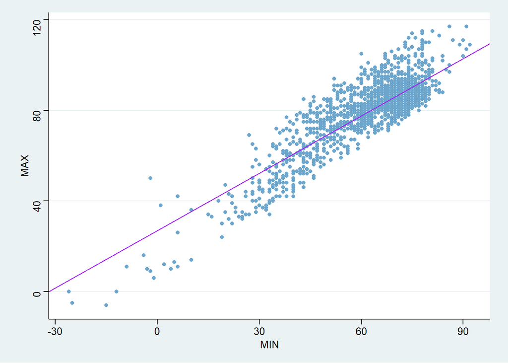

```r
myrlm <- rlm(MAX ~ MIN, data = dat)
#pander(summary(myrlm))
b <- myrlm$coefficients

dat %>%
  ggplot(aes(y = MAX , x = MIN)) +
  geom_point(col = "skyblue3") +
  geom_abline(slope = b[2], intercept = b[1], col = "purple") +
  theme_stata()
```

Our eye can tell that clearly a robust regression is not the best for this data. There is much less data collected for cold days, and these days have unfair weight with the simple and now weight at all in the robust regression. It seems as though our best bet for prediction though this will kill interpret-ability, is the loess curve. Our final plot will be as follows:

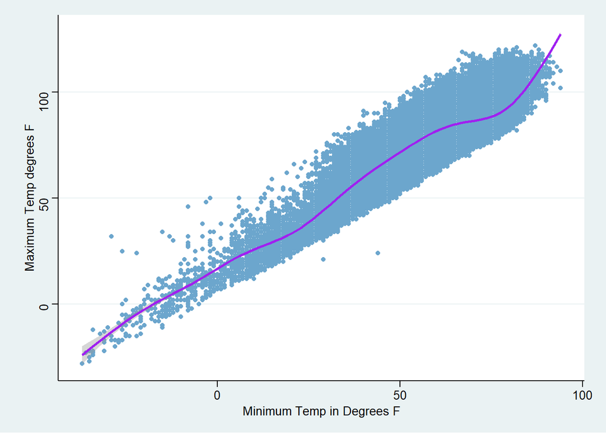

```r
#After some thought, it seems as though the robust line is not a good fit either. The robust line seems to miss the majority of the points in the middle of the blob. We are going to use a loess model as our final predicting model.

myloess <- loess(MAX ~ MIN, data = ww2)

ww2 %>%
  ggplot(aes(y = MAX , x = MIN)) +
  geom_point(col = "skyblue3") +
  geom_smooth(col = "purple") +
  theme_stata() +
  labs(x = "Minimum Temp in Degrees F", y = "Maximum Temp degrees F", main = "Loess prediction of High temp based on Low")
```

## Model Prediction

```r
pander(predict(myloess, data.frame(MIN = 45), interval = "prediction"))
```

| 1 |
| --- |
| 66.31 |

```r
pander(predict(myloess, data.frame(MIN = 45), interval = "confidence"))
```

| 1 |
| --- |
| 66.31 |

**Model Validation not appropriate for this data due to the lacking nature of both the simple linear and the robust regression**